# 等高线图

庄闪闪

2020-12-01

# 等高线图

**等高线图（contour map）** 是[可视化二维空间标量场的基本方法](https://github.com/EasyChart/Beautiful-Visualization-with-R)，可以将三维数据使用二维的方法可视化，同时用颜色视觉特征表示第三维数据，如地图上的等高线、天气预报中的等压线和等温线等。假设 $f(x, y)$ 是在点 $(x, y)$ 处的数值，等值线是在二维数据场中满足 $f(x, y)=c$ 的空间点集按一定的顺序连接而成的线。数值为c的等值线可以将二维空间标量场分为两部分：如果 函数大于c，则该点在等值线内；反之，则该点在等值线外。

```r
library(directlabels)
library(reshape2)
library(ggplot2)
library(grDevices)
library(RColorBrewer)
```

## 数据介绍

```r
rf <- colorRampPalette(rev(brewer.pal(11,'Spectral')))
colormap <- colorRampPalette(rev(brewer.pal(11,'Spectral')))(32)
# 数据
z <- as.matrix(read.table("等高线.txt",header=TRUE))
colnames(z) <- seq(1,ncol(z),by=1) #列名设置
max_z <- max(z)
min_z <- min(z)
breaks_lines <- seq(min(z),max(z),by=(max_z-min_z)/10)
map <- melt(z) #这个函数来自reshape2（处理数据的包）介绍一下这个函数，以及相关函数
colnames(map)<-c("Var1","Var2","value")
```

```r
knitr::kable(head(z[,1:10]),caption = "转换前数据")
```

转换前数据

| 1 | 2 | 3 | 4 | 5 | 6 | 7 | 8 | 9 | 10 |
| --- | --- | --- | --- | --- | --- | --- | --- | --- | --- |
| 1076 | 1067 | 1060 | 1063 | 1076 | 1078 | 1073 | 1071 | 1073 | 1086 |
| 1083 | 1074 | 1065 | 1075 | 1091 | 1090 | 1082 | 1083 | 1087 | 1097 |
| 1087 | 1085 | 1079 | 1083 | 1101 | 1102 | 1094 | 1098 | 1105 | 1108 |
| 1087 | 1089 | 1089 | 1092 | 1106 | 1111 | 1109 | 1116 | 1118 | 1122 |
| 1089 | 1093 | 1095 | 1100 | 1112 | 1124 | 1129 | 1135 | 1134 | 1137 |
| 1094 | 1104 | 1103 | 1103 | 1117 | 1138 | 1149 | 1154 | 1155 | 1150 |

```r
knitr::kable(head(map),caption = "转换后数据")
```

转换后数据

| Var1 | Var2 | value |
| --- | --- | --- |
| 1 | 1 | 1076 |
| 2 | 1 | 1083 |
| 3 | 1 | 1087 |
| 4 | 1 | 1087 |
| 5 | 1 | 1089 |
| 6 | 1 | 1094 |

## 热力分布图

使用ggplot2包中的`geom_tile()`或者`geom_raster()`绘制热 力分布图。其主要区别在于`geom_raster()`函数中存在`interpolate=TRUE/FALSE`这个参数，决定是否对热力图进行平滑处理。

这里使用`geom_tile()`进行演示，将三维数据`(x,y,z)`中`(x,y)`表示位置信息，`z`映射到颜色。这里的`scale_fill_gradientn()`将颜色填充呈n个梯度。

- **拓展：**`scale_*_gradient`创建一个双色梯度(低-高)，`scale_*_gradient2`创建一个渐变的颜色梯度(低-中-高)，`scale_*_gradientn`创建一个n色梯度。

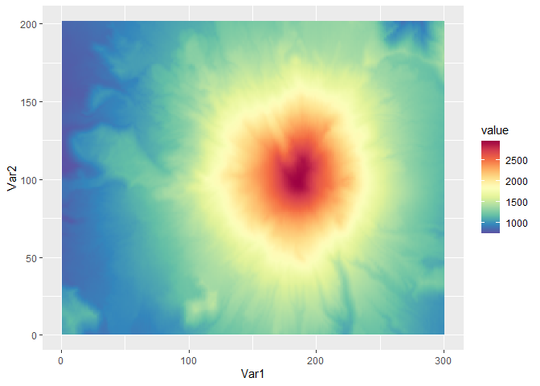

```r
ggplot(map,aes(x=Var1,y=Var2,z=value))+
    geom_tile(aes(fill=value))+
    scale_fill_gradientn(colours=colormap)
```

## 添加等高线

使用`geom_contour()`在上图基础上添加等高线，同一轮廓上的数值相同。

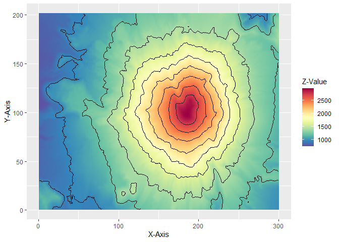

```r
ggplot(map,aes(x=Var1,y=Var2,z=value))+
    geom_tile(aes(fill=value))+#根据高度填充
    scale_fill_gradientn(colours=colormap)+
    geom_contour(breaks=breaks_lines,color="black")+#
    labs(x="X-Axis",y="Y-Axis",fill="Z-Value")
```

## 设置主题

对主题进行稍微的调整。改变x轴题目(`axis.title`,大小为15，字体形式为常规体`face="plain"`，颜色黑色)，x轴文字(`axis.text`),图例标题(`legend.title`)图例文字,(`legend.text`),(图例背景`legend.background`),图例位置(`legend.position`)

- *拓展*：face还可以设置其他字体形式：plain（常规体）、bold（粗体）、italic（斜体）、bold.italic（粗斜体）

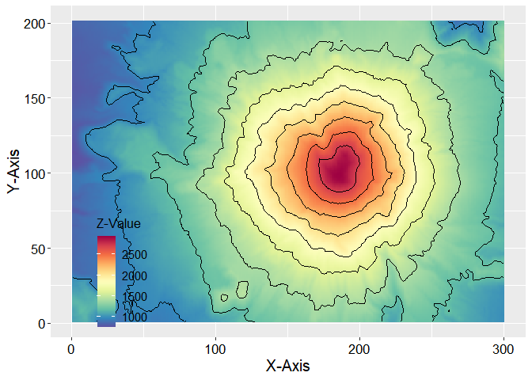

```r
Contour <- ggplot(map,aes(x=Var1,y=Var2,z=value))+
    geom_tile(aes(fill=value))+#根据高度填充
    scale_fill_gradientn(colours=colormap)+
    geom_contour(aes(colour= ..level..),breaks=breaks_lines,color="black")+#
    labs(x="X-Axis",y="Y-Axis",fill="Z-Value")+
    theme(
        axis.title = element_text(size=15,face="plain",color="black"),
        axis.text = element_text(size=13,face="plain",color="black"),
        legend.title = element_text(size=13,face="plain",color="black"),
        legend.text = element_text(size=11,face="plain",color="black"),
        legend.background = element_blank(),
        legend.position = c(0.15,0.2)
    )
Contour
```

## 添加等高线的具体数值

在上面的图基础上，添加等高线的具体数值，从而不需要颜色映射的图例，同一轮廓上的数值相同。

- **作用**：在二维屏幕上，等高线可以有效地表达相同数值的区域，揭示走势和陡峭程度及两者之间的关系，寻找坡、峰、谷等形状。

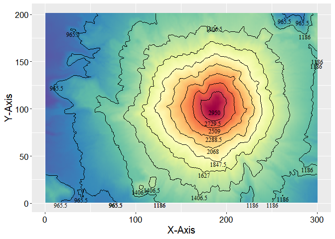

```r
direct.label(Contour, list("bottom.pieces", cex=0.8,                                                     fontface="plain", fontfamily="serif", colour='black'))
```